# A07

Olivia Martin

2022-11-07

**Instructions.** Change the author name on line 3 to be your name. Insert all requested answers. Upload in Moodle this file and a knitted file (html, doc, or pdf).

### Exercise 1 (60 points).

Answer the following reading questions (Read) and problems (Prob) from *Statistical Modeling: End-of-Chapter Exercises* by Daniel Kaplan. You should not need to refer to Kaplan, although his multiple choice answers to some problems may provide greater confidence when coming up with your answers.

**Read 8.01 (4 points).** What is a residual? Why does it make sense to make them small when fitting a model?

A residual is the difference between an observed value and a model’s prediction of that value. When fitting a model you want them to be small because that means minimizing the difference between the model’s prediction and real-world results; in reductive terms, it makes the model more accurate.

**Read 8.02 (4 points).** What is “least squares?”

Least squares is a way to determine goodness of fit by minimizing the sum of the squares of the residuals. This makes negative residuals count the same way as positive ones, and places a lot of weight on very large residuals.

**Read 8.03 (4 points).** What does it mean to “partition variability” using a model?

This refers to a special property of variance that applies to least-squared models as well as the basic groupwise models we’ve covered before. The variance can partition variability into two sections: how much of the variation in the data is associated with the model values (i.e., how much variation is explained by the model), and how much of the variation is associated with the residuals (i.e., how much variation the model does not explain).

**Read 8.04 (4 points).** How can a model term be redundant? Why are redundant terms a problem?

Redundancy occurs when one of the model terms is linearly dependent on another model term, so that one of the variables could provide the data for both. Redundant variables become an issue when interpreting a model because zero coefficients can give the mistaken impression that a redundant variable is not an important explanatory factor.

**Prob 8.01 (20 points)**. Here are some (made-up) data from an experiment growing trees. The height was measured for trees in different locations that had been watered and fertilized in different ways.

| height | water | light | compost | nitrogen |
| --- | --- | --- | --- | --- |
| 5 | 2.0 | shady | none | little |
| 4 | 1.0 | bright | none | lot |
| 5 | 1.5 | bright | some | little |
| 6 | 3.0 | shady | rich | lot |
| 7 | 3.0 | bright | some | little |
| 6 | 2.0 | shady | rich | lot |

1. (2 points) In the model expression height ∼ water, which is the explanatory variable?

   Water is the explanatory variable.
2. (4 points) Ranger Alan proposes the specific model formula

   `height = 2 ∗ water + 1`.

Fill in the following table.

| height | water | model values | residuals |
| --- | --- | --- | --- |
| 5.0 | 2.0 | 5.0 | 0.0 |
| 4.0 | 1.0 | 3.0 | 1.0 |
| 5.0 | 1.5 | 4.0 | 1.0 |
| 6.0 | 3.0 | 7.0 | -1.0 |
| 7.0 | 3.0 | 7.0 | 0.0 |
| 6.0 | 2.0 | 5.0 | 1.0 |

3. (4 points) Ranger Bill proposes the specific model formula

   `height = water + 3`.

Fill in the following table.

| height | water | model values | residuals |
| --- | --- | --- | --- |
| 5.0 | 2.0 | 5.0 | 0.0 |
| 4.0 | 1.0 | 4.0 | 0.0 |
| 5.0 | 1.5 | 4.5 | 0.5 |
| 6.0 | 3.0 | 6.0 | 0.0 |
| 7.0 | 3.0 | 6.0 | 1.0 |
| 6.0 | 2.0 | 5.0 | 1.0 |

4. (2 points) Based on your answers to the previous two parts, which of the two models is better? Give a specific definition of “better” and explain your answer quantitatively.

   Ranger Alan’s model has the sum of squared residuals 1.0+1.0+1.0+1.0 = 4.0, while Ranger Bill’s model has sum of squared residuals 0.25+1.0+1.0 = 2.25. Based on the least squares criterion, Ranger Bill’s model is better because the sum of squared residuals is lower.
5. (2 points) Write down the set of indicator variables that arise from the categorical variable `compost`.

   The indicator variables are none, some, and rich.
6. (2 points) The fitted values are exactly the same for the two models `water ∼ compost` and `water ∼ compost-1`. This suggests that the 1 vector (1, 1, 1, 1, 1, 1) is redundant with the set of indicator variables due to the variable `compost`. Explain why this redundancy occurs. Is it because of something special about the `compost` variable?

   Since compost is a categorical variable, the model `water ~ compost` consists of the average amount of water for each level of compost. There is no intercept term because the model isn’t linear, so suppressing it does nothing.
7. (2 points) Estimate, as best you can using only very simple calculations, the coefficients on the model `water ∼ compost-1`. (Note: there is no intercept term in this model.)

   For no compost the average water is 1.5, for some compost the average water is 2.25, and for rich compost the average water is 2.5. In model terms, you’d have something like `compost = 1.5`, `compostSome = 0.75`, and `compostRich = 1`.
8. (2 points) Ranger Charley observes that the following model is perfect because all of the residuals are zero.

   `height ∼ 1 + water + light + compost + nitrogen`

Charley believes that using this model will enable him to make excellent predictions about the height of trees in the future. Ranger Donald, on the other hand, calls Charley’s regression “ridiculous rot” and claims that Charley’s explanatory terms could fit perfectly any set of 6 numbers. Donald says that the perfect fit of Charley’s model does not give any evidence that the model is of any use whatsoever. Who do you think is right, Donald or Charley?

It’s really kind of hard to tell who’s right because of how small and fake this data set is. That said, there are a LOT of terms in this regression, and with that many categorical variables and so little data you could easily make a precise fit that doesn’t really mean much. I think “ridiculous rot” is kind of a strong term for a forest ranger to use about linear regression, but I guess Donald is free to go off at whatever level of severity he sees fit.

**Prob 8.03 (10 points).** Here is a simple model that relates foot width to length in children, fit to the data in `KidsFeet`:

```r
mod = lm(width ~ length, data = KidsFeet)
coef(mod)
```

```
## (Intercept)      length
##   2.8622761   0.2479478
```

Each of the following exercise parts can be answered with a code chunk.

1. (2 points) Using the coefficients, calculate the predicted foot width from this model for a child with foot length 27cm.

   ```r
   footwidth = function(length) {
     2.8622761+length*0.2479478}
   footwidth(27)
   ```

   ```
   ## [1] 9.556867
   ```

2. (2 points) The sum of squares of the residuals from the model provides a simple indication of how far typical values are from the model. In this sense, the standard deviation of the residuals tells us how much uncertainty there is in the prediction. (Later on, we’ll see that another term needs to be added to this uncertainty.) What is the sum of squares of the residuals?

   ```r
   deviance(mod)
   ```

   ```
   ## [1] 5.81203
   ```

3. (2 points) What is the sum of squares of the fitted values for the kids in `KidsFeet`?

   ```r
   sum(footwidth(KidsFeet$length)^2)
   ```

   ```
   ## [1] 3157.659
   ```

4. (2 points) What is the sum of squares of the foot widths for the kids in `KidsFeet`?

   ```r
   sum(KidsFeet$width^2)
   ```

   ```
   ## [1] 3163.47
   ```

5. (2 points) There is a simple relationship among the sum of squares of the response variable, the residuals, and the fitted values. You can confirm this directly. Write a code chunk that confirms the relationship.

   ```r
   sum(footwidth(KidsFeet$length)^2) + deviance(mod)
   ```

   ```
   ## [1] 3163.471
   ```

   ```r
   #there is slight rounding error in the function footwidth that accounts for the 0.001 difference
   ```

**Prob 8.05 (14 points).** The “modern physics” course has a lab where students measure the speed of sound. The apparatus consists of an air-filled tube with a sound generator at one end and a microphone that can be set at any specified position within the tube. Using an oscilloscope, the transit time between the sound generator and microphone can be measured precisely. Knowing the position $p$ and transit time $t$ allows the speed of sound $v$ to be calculated, based on the simple model:

```
`distance = velocity × time` or $p = vt$.
```

Here are some data recorded by a student group calling themselves “CDT”.

| position (m) | transit time (millisec) |
| --- | --- |
| 0.2 | 0.6839 |
| 0.4 | 1.252 |
| 0.6 | 1.852 |
| 0.8 | 2.458 |
| 1.0 | 3.097 |
| 1.2 | 3.619 |
| 1.4 | 4.181 |

Part 1. (2 points) Create a tibble with these data in a code chunk.

```r
CDT = tibble('p' = c(0.2, 0.4, 0.6, 0.8, 1.0, 1.2, 1.4), 't' = c(0.6839, 1.252, 1.852, 2.458, 3.097, 3.619, 4.181))
```

(2 points) Then fit an appropriate model. Note that the relationship $p = vt$ between position, velocity, and time translates into a statistical model of the form `p ∼ t - 1` where the velocity will be the coefficient on the `t` term.

```r
CDT_mod = lm(p~t-1, CDT)
coef(CDT_mod)
```

```
##         t
## 0.3291336
```

(2 points) What are the units of the model coefficient corresponding to velocity, given the form of the data in the table above?

Meters per millisecond

Compare the velocity you find from your model fit to the accepted velocity of sound (at room temperature, at sea level, in dry air): 343 m/s. There should be a reasonable match. If not, check whether your data were entered properly and whether you specified your model correctly.

The velocity of sound I got was 329 m/s, which seems fairly reasonable, though I don’t know enough about physics to know for sure. That said, I did check my data entry and model specification, and it looks correct, so I assume this is close enough.

Part 2. The students who recorded the data wrote down the transit time to 4 digits of precision, but recorded the position to only 1 or 2 digits, although they might simply have left off the trailing zeros that would indicate a higher precision. Use the data to find out how precise the position measurement is. To do this, make two assumptions that are very reasonable in this case:

1. The velocity model is highly accurate, that is, sound travels at a constant velocity through the tube.
2. The transit time measurements are correct. This assumption reflects current technology. Time measurements can be made very precisely, even with inexpensive equipment.

Given these assumptions, you should be able to calculate the position from the transit time and velocity. If the measured position differs from this model value — as reflected by the residuals — then the measured position is imprecise. So, a reasonable way to infer the precision of the position is by the typical size of residuals. How big is a typical residual? One appropriate way to measure this is with the standard deviation of the residuals.

(2 points) Give a numerical value for this.

```r
sd(resid(CDT_mod))
```

```
## [1] 0.0169083
```

Part 3. The students’ lab report doesn’t indicate how they know for certain that the sound generator is at position zero. One way to figure this out is to measure the generator’s position from the data themselves. Denoting the actual position of the sound generator as $p_0$, then the equation relating position and transit time is

```
$p − p_0 = vt$ or $p = p_0 + vt$.
```

This suggests fitting a model of the form `p ∼ 1 + t`, where the coefficient on 1 will be $p_0$ and the coefficient on `t` will be $v$.

(2 points) Fit this model to the data.

```r
CDT_mod2 = lm(p~1+t, data = CDT)
coef(CDT_mod2)
```

```
## (Intercept)           t
## -0.03221764  0.33982135
```

(2 points) What is the estimated value of $p_0$?

-0.03 m, but using the precision given in the table, it would be 0.0 m.

Notice that adding new terms to the model reduces the standard deviation of the residuals.

(2 points) What is the new value of the standard deviation of the residuals?

```r
sd(resid(CDT_mod2))
```

```
## [1] 0.01006702
```

Compare the estimated speed of sound found from the model `p ∼ t` to the established value: 343 m/s. Notice that the estimate is better than the one from the model `p ∼ t - 1` that didn’t take into account the position of the sound generator.

The new estimate is 340 m/s, which is much closer.

### Exercise 2 (24 points).

Consider the following scatter plot of five data points and the three models represented by colored lines.

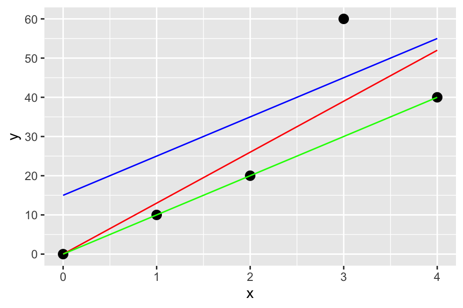

1. (2 points) By just looking at the graphic, which line do you think best captures the trend of the data? Explain.

   I don’t think I have enough context to make that call. (3,60) looks like it could be a mistake or an outlier of the type that should be removed. If that is the case, then the green line captures the best trend of the data. If (3,60) is a valid data point, then I would choose the red line because the five large residuals will probably sum to more than the four smaller ones and one very large one.
2. (12 points) Complete the following table.

| x | y | Residuals | red | green | blue |
| --- | --- | --- | --- | --- | --- |
| 0 | 0 |  | 0 | 0 | -15 |
| 1 | 10 |  | -3 | 0 | -15 |
| 2 | 20 |  | -6 | 0 | -15 |
| 3 | 60 |  | 21 | 30 | 15 |
| 4 | 40 |  | -12 | 0 | -15 |
|  |  | sum absolute | 42 | 30 | 75 |
|  |  | sum squared | 630 | 900 | 1125 |
|  |  | max absolute | 21 | 30 | 15 |

3. (2 points) Which line has the smallest sum of absolute residuals?

   Green
4. (2 points) Which line has the smallest sum of squared residuals?

   Red
5. (2 points) Which line has the smallest maximum absolute residual?

   Blue
6. (2 points) Which line is usually chosen by statisticians to be the best line?

   Red
7. (2 points) Does the numerical work in parts (b) - (f) change the choice you made in part (a)? Explain.